# Development of a Biomarker Signature using Grating coupled Fluorescence Plasmonic Microarray for diagnosis of MIS-C

Microbiome data analysis

Load all necessary packages. pacman will install and load any missing packages.

```r
if (!require("pacman")) install.packages("pacman")
```

```r
pacman::p_load(decontam, phyloseq, BiocManager, qiime2R, DESeq2, tidyverse, RColorBrewer, viridis, vegan, pheatmap, ggplot2, patchwork, ggpubr, ranacapa, nlme, compositions, readr, devtools, microViz, ANCOMBC, microbiome, GUniFrac, scales, DT)
```

Use the Qiime2R plugin to import .qza files from Qiime2 into phyloseq.

```r
phy = qza_to_phyloseq("filtered-table.qza", "rooted-tree.qza", "taxonomy.qza", "metadata.txt",tmp = "C:/tmp")
```

Replace underscores in the taxonomy with spaces (e.g. “Escherichia_coli” becomes “Escherichia coli”).

```r
phy@tax_table = gsub("_", " ", phy@tax_table)
head(phy@tax_table)
```

```
## Taxonomy Table:     [6 taxa by 7 taxonomic ranks]:
##                                  Kingdom    Phylum       Class
## 1d8ed5d8daac3c7f0d06a099b9ac3fde "Bacteria" "Firmicutes" "Bacilli"
## 14e16b9ab502eea1c89aa1a9ece5d9cb "Bacteria" "Firmicutes" "Negativicutes"
## f1b6c4972ebf6c978dc392be24d20cdb "Bacteria" "Firmicutes" "Bacilli"
## 6c32c2cc7e8a3316f8bb5b83d15e3daa "Bacteria" "Firmicutes" "Bacilli"
## 4e89160f5110b33efa3cb0c3173edc6a "Bacteria" "Firmicutes" "Bacilli"
## c2b0ab9451f8d75cf3e730d3e556ce48 "Bacteria" "Firmicutes" "Bacilli"
##                                  Order             Family
## 1d8ed5d8daac3c7f0d06a099b9ac3fde "Lactobacillales" "Streptococcaceae"
## 14e16b9ab502eea1c89aa1a9ece5d9cb "Veillonellales"  "Veillonellaceae"
## f1b6c4972ebf6c978dc392be24d20cdb "Lactobacillales" "Streptococcaceae"
## 6c32c2cc7e8a3316f8bb5b83d15e3daa "Lactobacillales" "Streptococcaceae"
## 4e89160f5110b33efa3cb0c3173edc6a "Lactobacillales" "Streptococcaceae"
## c2b0ab9451f8d75cf3e730d3e556ce48 "Lactobacillales" "Streptococcaceae"
##                                  Genus           Species
## 1d8ed5d8daac3c7f0d06a099b9ac3fde "Streptococcus" "Streptococcus unclassified"
## 14e16b9ab502eea1c89aa1a9ece5d9cb "Veillonella"   "Veillonella unclassified"
## f1b6c4972ebf6c978dc392be24d20cdb "Streptococcus" "Streptococcus unclassified"
## 6c32c2cc7e8a3316f8bb5b83d15e3daa "Streptococcus" "Streptococcus unclassified"
## 4e89160f5110b33efa3cb0c3173edc6a "Streptococcus" "Streptococcus unclassified"
## c2b0ab9451f8d75cf3e730d3e556ce48 "Streptococcus" "Streptococcus unclassified"
```

Use negative controls to identify and remove likely contaminants.

```r
sample_data(phy)$is.neg <- sample_data(phy)$Sample_or_Control == "Control Sample"
contamdf.prev <- isContaminant(phy, method="prevalence", neg="is.neg")
table(contamdf.prev$contaminant)
```

```
##
## FALSE  TRUE
## 11646     6
```

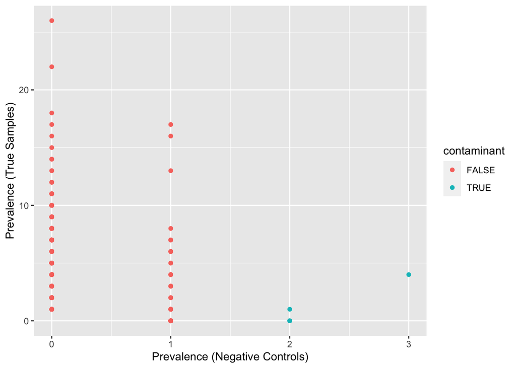

```r
phy.pa <- transform_sample_counts(phy, function(abund) 1*(abund>0))
phy.pa.neg <- prune_samples(sample_data(phy.pa)$Sample_or_Control == "Control Sample", phy.pa)
phy.pa.pos <- prune_samples(sample_data(phy.pa)$Sample_or_Control == "True Sample", phy.pa)
df.pa <- data.frame(pa.pos=taxa_sums(phy.pa.pos), pa.neg=taxa_sums(phy.pa.neg),
                      contaminant=contamdf.prev$contaminant)
ggplot(data=df.pa, aes(x=pa.neg, y=pa.pos, color=contaminant)) + geom_point() +
  xlab("Prevalence (Negative Controls)") + ylab("Prevalence (True Samples)")
```

```r
phy <- prune_taxa(!contamdf.prev$contaminant, phy)
ntaxa(phy)
```

```
## [1] 11646
```

Subset controls out of the phyloseq object with phy_subset. Here, we use the metadata column “Type” to keep only samples with the value “Saliva”

```r
phy_subset = subset_samples(phy, Type == "Saliva")
head(phy_subset@sam_data)
```

```
##             Run Sample_or_Control   Type Country InitialOrFollowUp  SubjectID
## A1_10024_I Run1       True Sample Saliva      US           Initial 2100410024
## A1_10029_I Run1       True Sample Saliva      US           Initial 2100410029
## A1_10050_I Run1       True Sample Saliva      US           Initial 2100410050
## A2_10072_I Run1       True Sample Saliva      US           Initial 2100410072
## A3_10048_I Run1       True Sample Saliva      US           Initial 2100410048
## A1_10040_I Run1       True Sample Saliva      US           Initial 2100410040
##            Followup   Study_ID suspected_dx definitive_dx Cohort
## A1_10024_I          2100410024            1             1     A1
## A1_10029_I          2100410029            1             1     A1
## A1_10050_I          2100410050            1             1     A1
## A2_10072_I          2100410072            2             2     A2
## A3_10048_I          2100410048            1             3     A3
## A1_10040_I          2100410040            1             1     A1
##            definitive_dx_other enroll_age enroll_age_noncalc covidtest_age1
## A1_10024_I                            139                               139
## A1_10029_I                             42                 42             42
## A1_10050_I                            142                               142
## A2_10072_I                             72                                72
## A3_10048_I                            186                               186
## A1_10040_I                            211                211
##            covidtest_age1_noncalc covid_history covid_history_times
## A1_10024_I
## A1_10029_I                     42
## A1_10050_I
## A2_10072_I
## A3_10048_I
## A1_10040_I                    211
##            slva_enrollmt_time slva_enrollmt_after_ivig
## A1_10024_I              12:09                        0
## A1_10029_I              15:30                        0
## A1_10050_I              12:09                        0
## A2_10072_I              16:30                        0
## A3_10048_I              15:18                        0
## A1_10040_I                                           0
##            slva_enrollment_after_antimicrobial
## A1_10024_I                                   0
## A1_10029_I                                   0
## A1_10050_I                                   0
## A2_10072_I                                   0
```

[output cut: 57 more lines]

```
## A1_10040_I                                   0                    1 White
##            Ethnicity TruncatedZIPcode    Sex Insurance Asthma Time TimeOfDay
## A1_10024_I        No               64   Male    Public    Yes 1209      Noon
## A1_10029_I        No               67   Male   Private     No 1530 Afternoon
## A1_10050_I        No               68   Male   Private     No 1209      Noon
## A2_10072_I        No               62   Male    Public     No 1630 Afternoon
## A3_10048_I        No               60 Female   Private     No 1518 Afternoon
## A1_10040_I        No                  Female   Private     No   NA   Unknown
##            Antibiotics CollectionMethod AgeGroup is.neg
## A1_10024_I          No             Swab   11-Jun  FALSE
## A1_10029_I          No             Swab    5-Feb  FALSE
## A1_10050_I          No     PassiveDrool   11-Jun  FALSE
## A2_10072_I          No             Swab   11-Jun  FALSE
## A3_10048_I          No     PassiveDrool   17-Dec  FALSE
## A1_10040_I          No     PassiveDrool   17-Dec  FALSE
```

Create a tsv file of the relative abundance values for each species in each sample. This can then be transferred to other GUI-based programs for further analysis.

```r
phydf <- phy %>% tax_glom(taxrank = "Species") %>%
        transform_sample_counts(function(x) {x/sum(x)}) %>%
        psmelt() %>% select(OTU, Species, Sample, Abundance) %>%
        spread(Sample, Abundance)

head(phydf)
```

```
##                                OTU                     Species   210040122_
## 1 016da3911c94fa87551f45654d8d2fc1    Actinomyces graevenitzii 0.1305212413
## 2 024995cba1f97e90c60f9d618ff43a97      Kingella denitrificans 0.0000000000
## 3 041b519e449917bb0cf891fa2fed810a      Granulicatella elegans 0.0031334739
## 4 05692795390d993b0d912fa89186a4ea      Leptotrichia hofstadii 0.0003012956
## 5 059af5109c00e91f48113d0598f19852 Streptococcus sp. KCOM 2412 0.0000000000
## 6 082e1f7845af0a0249c41d7d889060d3  Negativicutes unclassified 0.0000000000
##    210040146_ 210040146_B_ 210040148_ 210040165_spit_  210040191_ A1_10024_I
## 1 0.010768293  0.018423418 0.00000000     0.001320059 0.108742479 0.00000000
## 2 0.000000000  0.000000000 0.00000000     0.000000000 0.000000000 0.00000000
## 3 0.001741503  0.002535627 0.04164965     0.007480337 0.001411275 0.02236789
## 4 0.000000000  0.000000000 0.00000000     0.000000000 0.000000000 0.00000000
## 5 0.000000000  0.000000000 0.00000000     0.000000000 0.000000000 0.00000000
## 6 0.000000000  0.000000000 0.00000000     0.000000000 0.000000000 0.01173944
##     A1_10029_I   A1_10040_I   A1_10050_I   A2_10056_I   A2_10057_I   A2_10072_I
```

[output cut: 55 more lines]

```r
write.table(phydf, file = "relative_abundance.species.tsv", sep = "\t", quote = F,
            row.names = F, col.names = T)
```

To create a barplot with microViz, first use tax_fix_interactive to open a browser to fix the names of taxa at unclassified levels. This command will give you a command to use in the next step.

```r
tax_fix_interactive(phy_subset)
```

```
## ------ tax_fix_interactive looks best fullscreen! ------
```

```
## Click red stop button or hit Esc in console to stop app!
```

```
## PhantomJS not found. You can install it with webshot::install_phantomjs(). If it is installed, please make sure the phantomjs executable can be found via the PATH variable.
```

Shiny applications not supported in static R Markdown documents

Next, enter the command from tax_fix_interactive:

```r
phy_fix<-phy_subset %>%
 tax_fix(
  min_length = 3,
  unknowns = c("Rothia unclassified", "Gemella unclassified", "Bacilli unclassified", "Schaalia unclassified", "Bacillus unclassified", "Massilia unclassified", "Aminipila unclassified", "Catonella unclassified", "Treponema unclassified", "Neisseria unclassified", "Acinetobacter unclassified", "Bulleidia unclassified", "Atopobium unclassified", "Clostridia unclassified", "Alistipes unclassified", "Unknown genus", "Unknown order", "Unknown class", "Unknown family", "Unknown genus unclassified", "Unknown family unclassified", "Parvimonas unclassified", "Colibacter unclassified", "Selenomonadaceae unclassified", "Actinomycetaceae unclassified", "Intestinibacter unclassified", "Peptoanaerobacter unclassified", "Mobiluncus unclassified", "Prevotella unclassified", "Mollicutes unclassified", "Clostridium unclassified", "Megasphaera unclassified", "Abiotrophia unclassified", "Trueperella unclassified", "Actinomyces unclassified", "Sphingobium unclassified", "Selenomonas unclassified", "Bacteroides unclassified", "Caecibacter unclassified", "Muribaculum unclassified", "Veillonella unclassified", "Bacteroidia unclassified", "Enterococcus unclassified", "Melaminivora unclassified", "Streptobacillus unclassified", "Fusobacterium unclassified", "Capnocytophaga unclassified", "Cloacibacterium unclassified", "Enterorhabdus unclassified", "Massilimicrobiota unclassified", "Senegalimassilia unclassified", "Oribacterium unclassified", "Leptotrichia unclassified", "Lactobacillus unclassified", "Actinobaculum unclassified", "Mogibacterium unclassified", "Streptococcus unclassified", "Campylobacter unclassified", "Negativicutes unclassified", "Prevotellaceae unclassified", "Granulicatella unclassified", "Friedmanniella unclassified", "Clostridiaceae unclassified", "Micrococcaceae unclassified", "Actinobacteria unclassified", "Carnobacterium unclassified", "Flavobacteriia unclassified", "Muribaculaceae unclassified", "Lachnospiraceae unclassified", "Spirochaetaceae unclassified", "Eggerthellaceae unclassified", "Streptococcaceae unclassified", "Veillonellaceae unclassified", "Novosphingobium unclassified", "Corynebacteriaceae unclassified", "Aerococcaceae unclassified", "Peptostreptococcaceae unclassified", "Pseudopropionibacterium unclassified", "Spirochaetia unclassified", "Janthinobacterium unclassified"),
  sep = " ", anon_unique = TRUE,
  suffix_rank = "classified"
 )
```

Finally, create a relative abundance stacked barplot. Here, samples are ordered by Cohort and labeled with their name from the metadata column “SubjectID.” The plot is rotated so bars are horizontal. The 20 most abundant taxa are listed, and the rest are grouped as “other.” The plot is then exported as a .tiff image file.

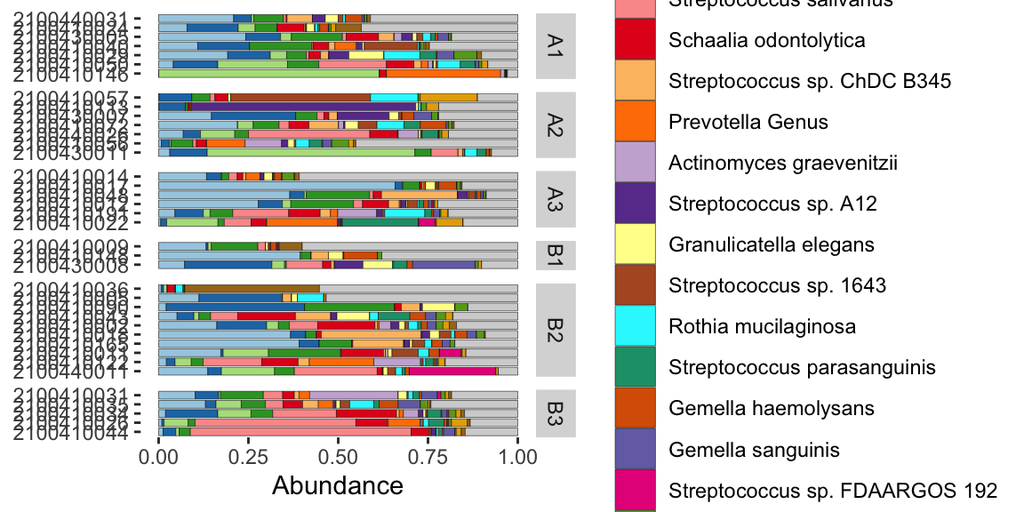

```r
phy_fix %>%
  ps_mutate(
    Cohort = factor(
      Cohort, levels = c("A1","A2","A3","B1","B2","B3"), ordered = TRUE)
  ) %>%
  comp_barplot(tax_level = "Species",
               label="SubjectID",
               n_taxa = 20,
               bar_width = 0.85,
               order_with_all_taxa = TRUE
               ) +
  facet_grid(
    rows = vars(Cohort),
    scales = "free", space = "free"
  ) +
  coord_flip() + guides(fill=guide_legend(ncol=1, reverse = TRUE, title="Species"))
```

```r
ggsave("speciesbarplot.tiff", device = "tiff", dpi = 300)
```